# Introduction

### Market Cap

On constate également que pour la colonne Market Cap elle aussi semble avoir plusieurs valeurs extrêmes.

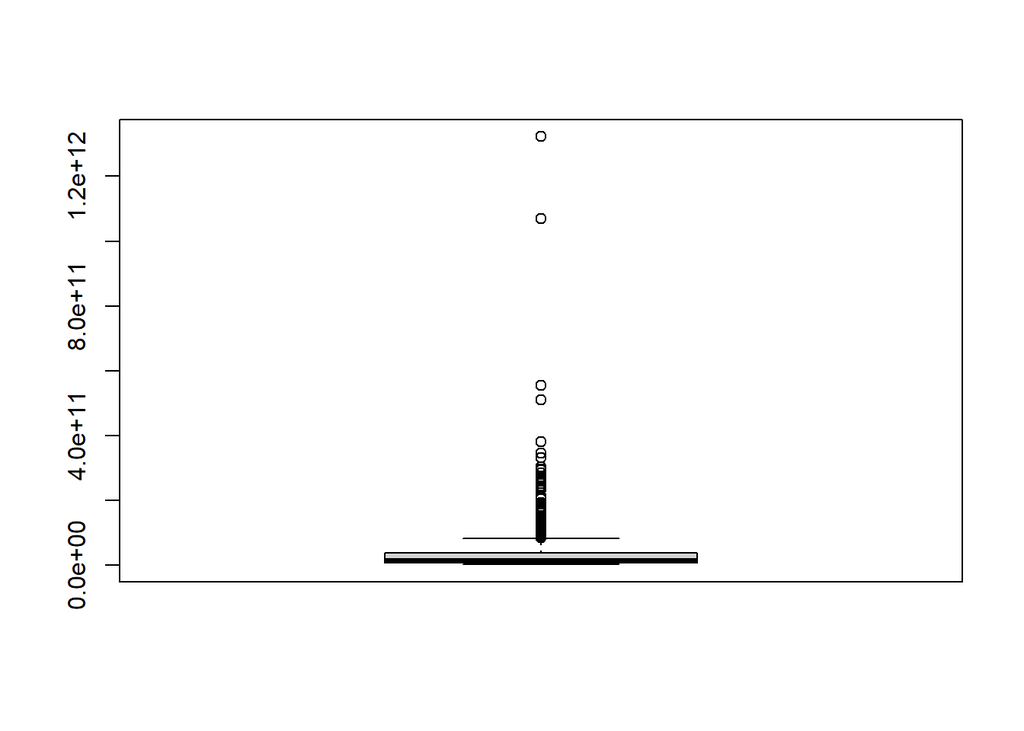

```r
boxplot(new_eurostoxx$`Market Cap`)
```

```r
summary(new_eurostoxx$`Market Cap`)
```

```
##      Min.   1st Qu.    Median      Mean   3rd Qu.      Max.
## 1.480e+09 5.555e+09 1.366e+10 4.131e+10 3.673e+10 1.322e+12
```

Plus de 11% des observations sur la colonne market cap sont des valeurs extrêmes.

```r
# Calculer les quartiles et la différence entre les quartiles
Q1 <- quantile(new_eurostoxx$`Market Cap`, 0.25, na.rm = TRUE)
Q3 <- quantile(new_eurostoxx$`Market Cap`, 0.75, na.rm = TRUE)
IQR <- Q3 - Q1

# Définir les limites inférieures et supérieures
limite_inférieure <- Q1 - 1.5 * IQR
limite_supérieure <- Q3 + 1.5 * IQR

# Identifier les valeurs aberrantes
Valeurs_aberrantes_MarketCap <- new_eurostoxx$`Market Cap`[new_eurostoxx$`Market Cap`< limite_inférieure| new_eurostoxx$`Market Cap` > limite_supérieure]
print(Valeurs_aberrantes_MarketCap)
```

```
##  [1] 9.136189e+10 1.163249e+11 9.866800e+10 9.261927e+10 1.327745e+11
##  [6] 9.158319e+10 2.504566e+11 2.957757e+11 9.846966e+10 1.707033e+11
## [11] 1.322439e+12 1.328977e+11 1.777388e+11 1.258699e+11 2.925140e+11
## [16] 2.128245e+11 1.207912e+11 1.402453e+11 1.743729e+11 1.068528e+12
## [21] 1.179889e+11 1.279923e+11 9.881069e+10 1.872379e+11 2.579534e+11
## [26] 2.359215e+11 1.058854e+11 1.696848e+11 1.655006e+11 1.074538e+11
## [31] 2.439182e+11 1.921001e+11 1.865174e+11 1.362679e+11 8.417718e+10
## [36] 2.102366e+11 3.445374e+11 8.769737e+10 1.008489e+11 8.924409e+10
## [41] 1.593779e+11 9.579771e+10 8.603840e+10 1.515597e+11 3.806447e+11
## [46] 1.019372e+11 1.336375e+11 1.126122e+11 9.915408e+10 8.356864e+10
## [51] 2.836362e+11 5.535871e+11 2.141963e+11 9.100866e+10 9.804963e+10
## [56] 3.317611e+11 2.688794e+11 5.099112e+11 2.331090e+11 1.217811e+11
## [61] 1.590819e+11 2.110723e+11 3.030842e+11 2.614380e+11 8.839471e+10
## [66] 2.029851e+11
```

```r
print(length(Valeurs_aberrantes_MarketCap)/length(new_eurostoxx$`Market Cap`))
```

```
## [1] 0.1191336
```

```r
#On constate que 12% des valeurs sur la colonne Market Cap sont des valeurs aberrantes
```

### Value - Board Structure/Independent Board Members

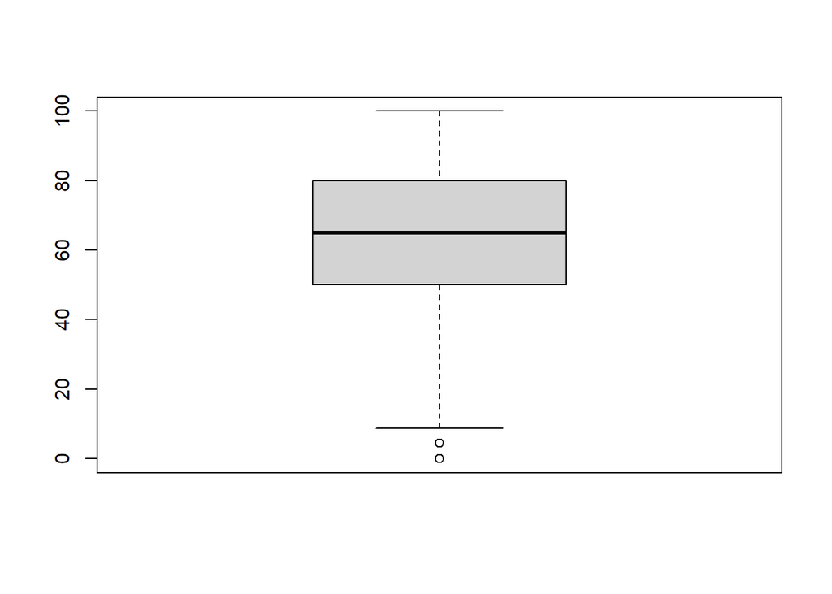

```r
boxplot(new_eurostoxx$`Value - Board Structure/Independent Board Members`)
```

```r
summary(new_eurostoxx$`Value - Board Structure/Independent Board Members`)
```

```
##    Min. 1st Qu.  Median    Mean 3rd Qu.    Max.
##    0.00   50.00   65.00   64.15   80.00  100.00
```

```r
# Calculer les quartiles et la différence entre les quartiles
Q1 <- quantile(new_eurostoxx$`Value - Board Structure/Independent Board Members`, 0.25, na.rm = TRUE)
Q3 <- quantile(new_eurostoxx$`Value - Board Structure/Independent Board Members`, 0.75, na.rm = TRUE)
IQR <- Q3 - Q1

# Définir les limites inférieures et supérieures
limite_inférieure <- Q1 - 1.5 * IQR
limite_supérieure <- Q3 + 1.5 * IQR

# Identifier les valeurs aberrantes
Valeurs_aberrantes_value <- new_eurostoxx$`Value - Board Structure/Independent Board Members`[new_eurostoxx$`Value - Board Structure/Independent Board Members`< limite_inférieure| new_eurostoxx$`Value - Board Structure/Independent Board Members` > limite_supérieure]
print(Valeurs_aberrantes_value)
```

```
##  [1] 4.55 0.00 0.00 0.00 0.00 0.00 0.00 0.00 0.00 0.00 0.00 0.00 0.00 0.00 0.00
## [16] 0.00 0.00 0.00
```

```r
print(length(Valeurs_aberrantes_value)/length(new_eurostoxx$`Value - Board Structure/Independent Board Members`))
```

```
## [1] 0.03249097
```

```r
#On constate que 3% des valeurs sur la colonne board structure sont aberrantes
```

Maintenant qu’on a fait une analyse des valeurs aberrantes, on peut en tirer que sur notre jeu de données, il y a une présence de plusieurs valeurs extrêmes qui peuvent par la suite impacter nos coefficients, voire même les biaiser. Pour cette raison, et afin de garantir les résulats les moins biaisés possible pour notre régression, on va traîter nos valeurs extrêmes. Pour cela, de nombreux choix s’offent à nous, et on va tenter de rapidement les expliquer et puis de justifier l’utilisation d’une de ces méthodes pour traîter nos valeurs aberrantes:

On va appliquer une windsorisation sur toutes les colonnes ou on a identifié la présence de valeurs aberrantes dans notre jeu de données:

```r
library(DescTools) #package qui inclut la fonctiton windsorisation

# Exclure "Environment Pillar Score" de la Winsorisation puisque celle-ci n'avait pas de valeurs aberrantes
eurostoxx_windsorize <- data.frame(lapply(names(new_eurostoxx), function(col_name) {
  col <- new_eurostoxx[[col_name]]  # Extraire la colonne
  if (is.numeric(col) && col_name != "Environment Pillar Score") {
    Winsorize(col, val = quantile(col, probs = c(0.1, 0.9), na.rm = TRUE))
  } else {
    col  # Garder les colonnes non numériques ou spécifiquement exclues inchangées
  }
}))

# Renommer les colonnes pour correspondre aux noms d'origine
colnames(eurostoxx_windsorize) <- colnames(new_eurostoxx)

# Afficher les données après Winsorisation
print(eurostoxx_windsorize)
```

```
##     COUNTRY OF DOMICIL Environment Pillar Score EMPLOYEES
## 1            Allemagne                    95.85   87597.0
## 2            Allemagne                    90.57  108154.7
## 3            Allemagne                    73.82   20654.0
## 4            Allemagne                    67.45    3232.0
## 5            Allemagne                    78.53  108154.7
## 6            Allemagne                    67.63   14304.0
## 7            Allemagne                    81.76  108154.7
## 8            Allemagne                    83.01   55047.0
## 9            Allemagne                    68.16   52450.0
## 10           Allemagne                    91.63   57036.0
## 11           Allemagne                    69.26   18490.0
## 12           Allemagne                    85.05    6853.0
## 13           Allemagne                    81.81   14332.0
## 14           Allemagne                    79.46   19792.0
```

[output cut: 2205 more lines]

A travers les digrammes en moustache suivants qu’on a produit tout à l’heure avant d’avoir fait notre traitement des valeurs aberrantes, on observe cependant une grande différence avec ces digrammes en moustaches qu’on a produit après la windorisation. Certes il reste encore des valeurs aberrrantes, mais ceci s’explique par le fait que nous sommes en présence de beaucoup de valeurs aberrantes qui sont utiles dans notre analyse et il serait donc irréaliste de ne plus en avoir du tout. Elles ont certes été réduites, mais elle sont encore présentes dans notre jeu de donnée mais de façon moins extrême, ce qui faussera moins les coefficients dans notre regression.

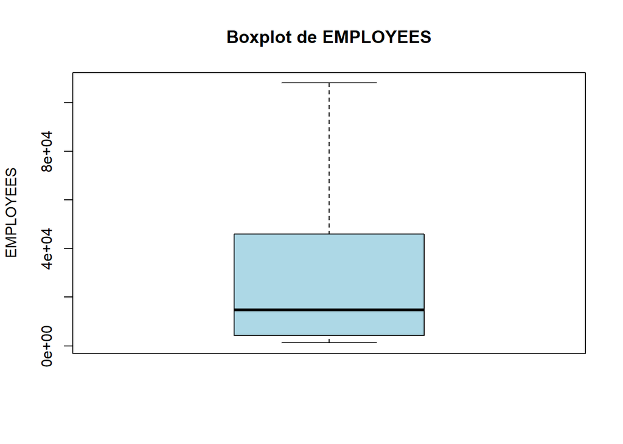

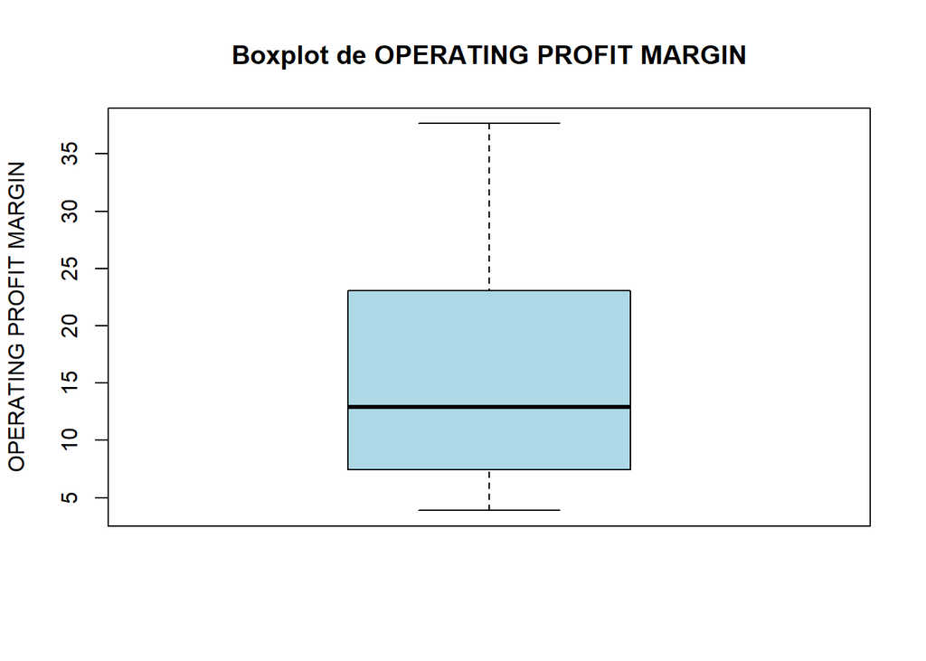

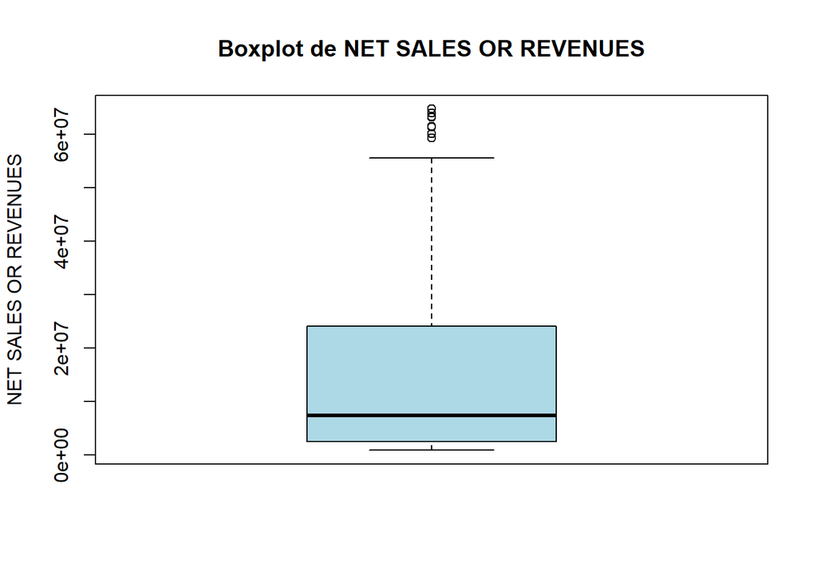

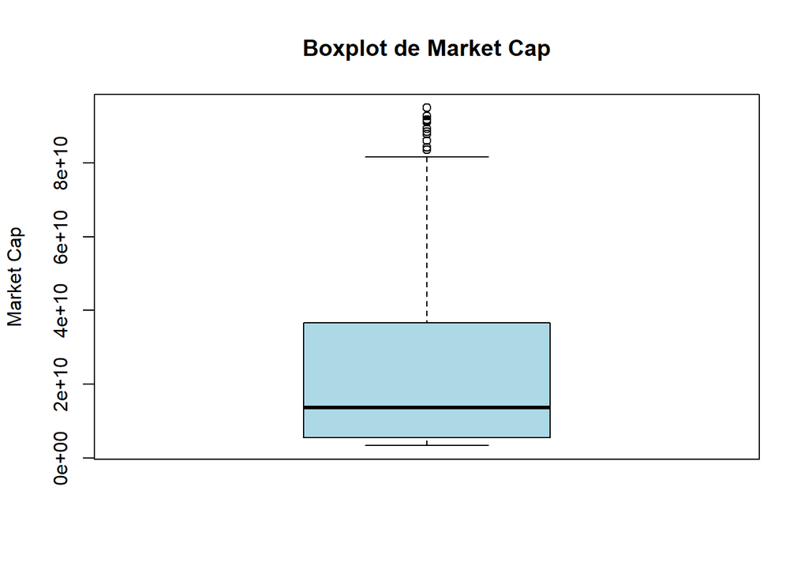

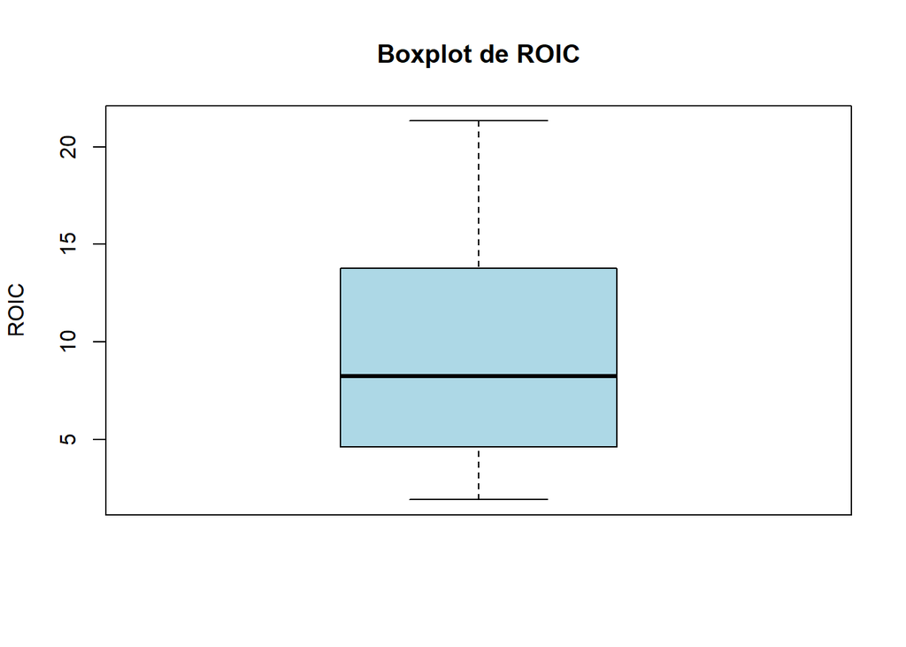

```r
colonnes <- c("EMPLOYEES", "OPERATING PROFIT MARGIN",
                     "NET SALES OR REVENUES", "Market Cap", "ROIC")

# Boucle pour tracer un boxplot pour chaque colonne
for (col in colonnes) {
  boxplot(eurostoxx_windsorize[[col]],
  main = paste("Boxplot de", col),
          ylab = col,
          col = "lightblue")
}
```

### C. Relations entre les variables (question 3)

On commence tout d’abord à effectuer quelques analyses graphiques en prenant soin à différencier entre nos variables qualitative et nos variables quantitatives. Le but de cette analyse est de mieux comprendre notre jeu de données et d’analyser les différentes relations qui existent entre nos variables afin de mieux saisir l’effet des différentes variables sur le environment pillar score qu’on cherche à expliquer.

```r
pander(summary(eurostoxx_windsorize))
```

Table continues below

| COUNTRY OF DOMICIL | Environment Pillar Score | EMPLOYEES |
| --- | --- | --- |
| Royaume-Uni:125 | Min. : 0.00 | Min. : 1213 |
| France : 69 | 1st Qu.:49.15 | 1st Qu.: 4267 |
| Allemagne : 63 | Median :69.01 | Median : 14682 |
| Suède : 57 | Mean :63.95 | Mean : 31018 |
| Suisse : 53 | 3rd Qu.:82.92 | 3rd Qu.: 45898 |
| Pays-Bas : 28 | Max. :98.16 | Max. :108155 |
| (Other) :159 | NA | NA |

Table continues below

| OPERATING PROFIT MARGIN | NET SALES OR REVENUES | Market Cap |
| --- | --- | --- |
| Min. : 3.890 | Min. : 888640 | Min. :3.431e+09 |
| 1st Qu.: 7.478 | 1st Qu.: 2540608 | 1st Qu.:5.555e+09 |
| Median :12.930 | Median : 7342750 | Median :1.366e+10 |
| Mean :16.244 | Mean :17345953 | Mean :2.768e+10 |
| 3rd Qu.:23.047 | 3rd Qu.:24053000 | 3rd Qu.:3.673e+10 |
| Max. :37.642 | Max. :64684500 | Max. :9.484e+10 |
| NA | NA | NA |

Table continues below

| ROIC | CSR Sustainability Committee | Value - Board Structure/Independent Board Members |
| --- | --- | --- |
| Min. : 1.913 | Oui:447 | Min. :37.22 |
| 1st Qu.: 4.622 | Non:107 | 1st Qu.:50.00 |
| Median : 8.230 | NA | Median :65.00 |
| Mean : 9.614 | NA | Mean :65.41 |
| 3rd Qu.:13.750 | NA | 3rd Qu.:80.00 |
| Max. :21.317 | NA | Max. :92.86 |
| NA | NA | NA |

| Fi |
| --- |
| Min. :-1.9600818 |
| 1st Qu.:-1.1218832 |
| Median :-0.0278789 |
| Mean :-0.0003015 |
| 3rd Qu.: 1.0085644 |
| Max. : 2.0996859 |
| NA |

Sur ce graphique on observe la distribution de la variable qu’on cherche à expliquer par pays. Ceci peut être intéressant pour comprendre et voir si un pays ou un groupe de pays a tendence à avoir un score environnemental plus ou moins élevé que d’autres.

Une chose que l’on remarque d’emblée sur le graphique est que tous les pays ne sont pas tous représentés équitablement. C’est à dire que certains pays sont beaucoup plus présents que d’autres et on plusieurs observations, tandis que certains pays sont représentés par une ou un nombre petits d’observations.

On observe que des pays comme le Portugal et l’Espagne qui n’ont pas un grand nombre d’observations semblent avoir en moyenne les scores les plus élevés. Ceci peut être expliqué par un biais d’autoselection ou seules les entreprises qui ont un score élevé sont représentée.

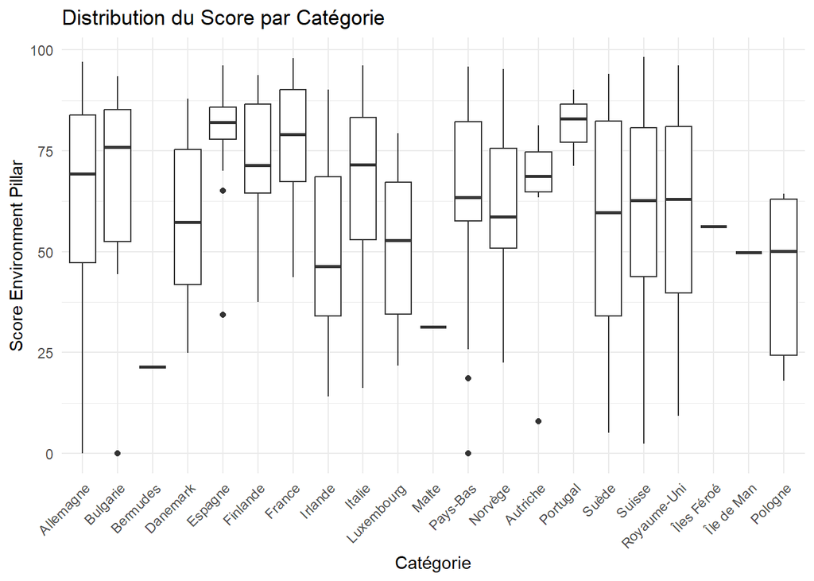

```r
library('ggplot2')
ggplot(eurostoxx_windsorize, aes(x = `COUNTRY OF DOMICIL`, y = `Environment Pillar Score`)) +
  geom_boxplot() +
  labs(title = "Distribution du Score par Catégorie",
       x = "Catégorie",
       y = "Score Environment Pillar") +
  theme_minimal() +
  #On ajoute cette ligne pour avoir le nom des pays affichés de façon claire avec une rotation de 45°
  theme(axis.text.x = element_text(angle = 45, hjust = 1))
```

Ce graphique représente la corrélation entre les différents variables quantitatives. La ligne qui nous intéresse le plus est celle qui représente ‘environment pillar score’ sur laquelle il semblerait que la majorité des variables aient une corrélation positive ou négative avec le score environnemental. Ceci nous indique que nous sommes sur la bonne piste pour plus tard construire notre modèle et comprendre si il s’agit de simples corrélations (comme représentées ici) ou alors si il y a bel et bien un effet de causalité entre nos variables explicatives et la variable du score environnemental.

```r
#Package pour la visualisation
library(GGally)
```

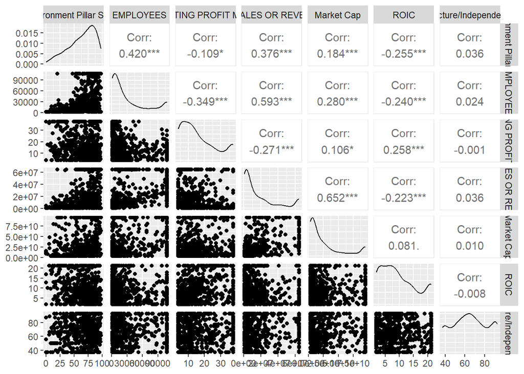

```r
ggpairs(eurostoxx_windsorize, columns = c("Environment Pillar Score", "EMPLOYEES","OPERATING PROFIT MARGIN", "NET SALES OR REVENUES","Market Cap","ROIC", "Value - Board Structure/Independent Board Members"))
```

Le graphique ci-dessous est une autre façon de visualiser la corrélation entre les différentes variables. On observe quelques corrélations entre nos variables explicatives comme ‘employees’ et ‘net sales & revenues’, ce qui est assez logique. Plus une entreprise sera grande, plus elle aura d’employés et aura tendence à réaliser un plus grand nombre de ventes et de revenues. On insistera cependant tout à l’heure sur notre modèle à vérifier comme nous ne sommes pas en présence de multicollinéarité. Le même phénomène est observé pour ‘market capitalization’ et ‘net sales & revenues’.

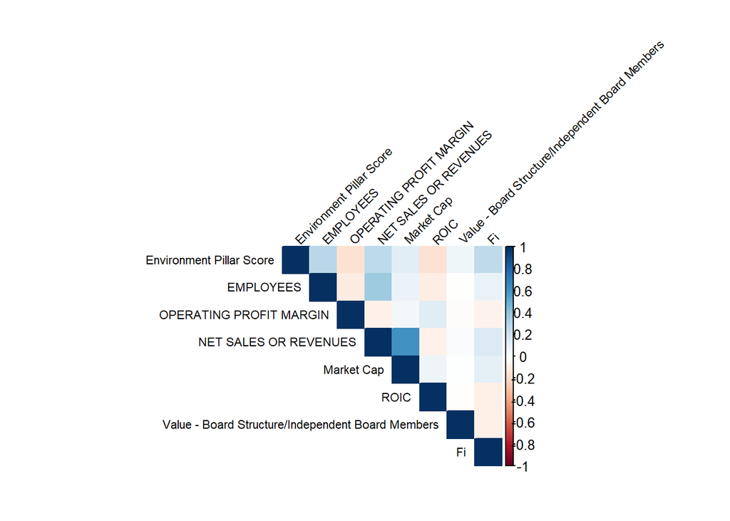

```r
library(corrplot)
library(dplyr)

# Sélectionner uniquement les colonnes numériques
numerique_eurostoxx <- new_eurostoxx %>% select_if(is.numeric)

# Calculer la matrice de corrélation
correlation_matrix <- cor(numerique_eurostoxx, use = "complete.obs")


# Afficher la heatmap
corrplot(correlation_matrix, method = "color", type = "upper", tl.col = "black", tl.srt = 45, tl.cex = 0.7)
```

Il semblerait qu’il y ait une relation positive entre le nombre d’employés et le score environnemental. Plus le nombre d’employés est grand, plus le score environnemental a tendence à augmenter. Ceci est assez logique puisque généralement, plus une entreprise est grande, le plus grand budget elle aura à consacrer plus améliorer son impact environnemental. (mais ceci n’est pas toujours vrai!).

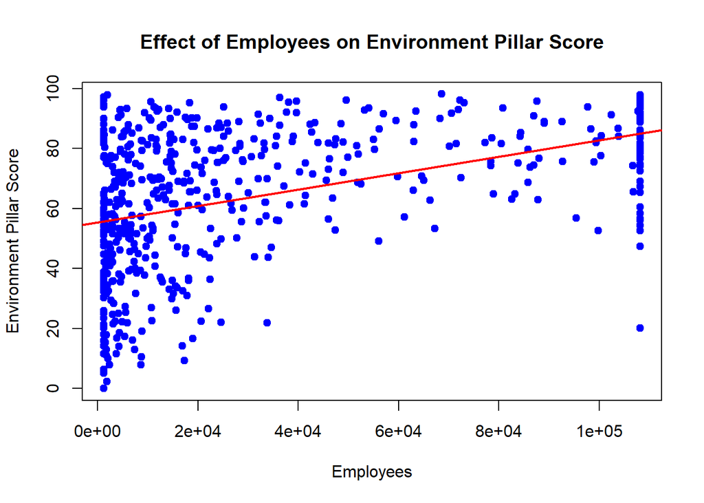

```r
plot(eurostoxx_windsorize$EMPLOYEES, eurostoxx_windsorize$`Environment Pillar Score`,
     main = "Effect of Employees on Environment Pillar Score",
     xlab = "Employees",
     ylab = "Environment Pillar Score",
     col = "blue", pch = 19)
abline(lm(eurostoxx_windsorize$`Environment Pillar Score` ~ eurostoxx_windsorize$EMPLOYEES), col = "red", lwd = 2)
```

Il ne semble pas y avoir de relation linéaire entre la variable operating profit margin et la variable environement pillar score. Le profit ne jouerait à priori donc pas de rôle important sur le score environnemental d’une entreprise, contrairement au nombre d’employés.

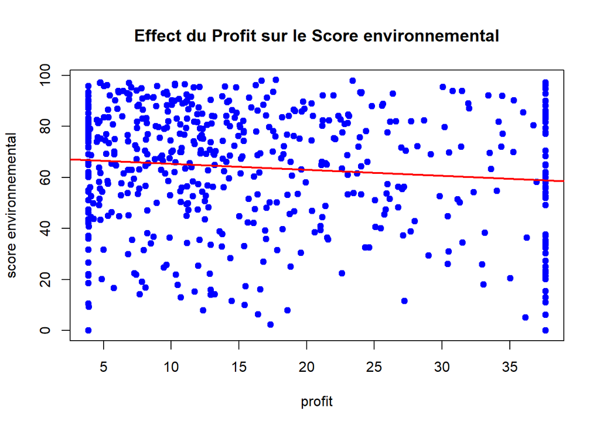

```r
plot(eurostoxx_windsorize$`OPERATING PROFIT MARGIN`, eurostoxx_windsorize$`Environment Pillar Score`,
     main = "Effect du Profit sur le Score environnemental",
     xlab = "profit",
     ylab = "score environnemental",
     col = "blue", pch = 19)
abline(lm(eurostoxx_windsorize$`Environment Pillar Score` ~ eurostoxx_windsorize$`OPERATING PROFIT MARGIN`), col = "red", lwd = 2)
```

Il semblerait cependant qu’il y ait une relation positive entre le revenu et le score environnemental. On remarque sur ce graphique que plus le revenue d’une entreprise augmente, plus le score environnemental aura également tendence à augmenter.

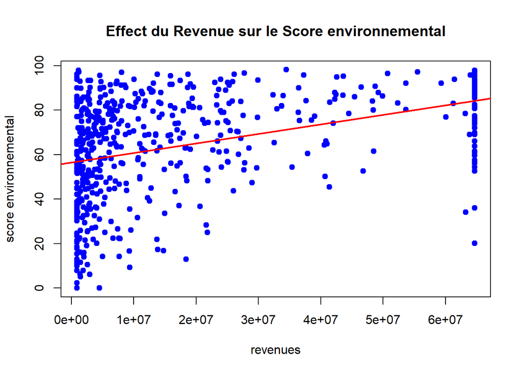

```r
plot(eurostoxx_windsorize$`NET SALES OR REVENUES`, eurostoxx_windsorize$`Environment Pillar Score`,
     main = "Effect du Revenue sur le Score environnemental",
     xlab = "revenues",
     ylab = "score environnemental",
     col = "blue", pch = 19)
abline(lm(eurostoxx_windsorize$`Environment Pillar Score` ~ eurostoxx_windsorize$`NET SALES OR REVENUES`), col = "red", lwd = 2)
```

Il ne semble cependant pas y avoir une relation entre la capitalization boursière et le score environnemental. On voit une légère relation positive, mais reste à voir si celle-ci sera significative dans notre modèle.

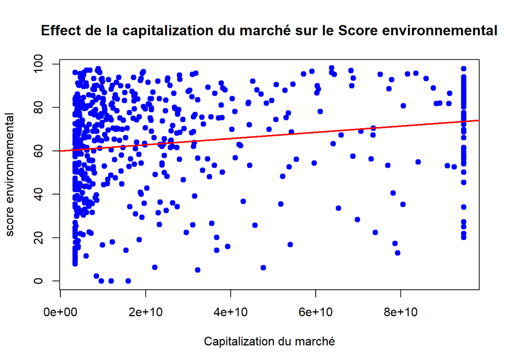

```r
plot(eurostoxx_windsorize$`Market Cap`, eurostoxx_windsorize$`Environment Pillar Score`,
     main = "Effect de la capitalization du marché sur le Score environnemental",
     xlab = "Capitalization du marché",
     ylab = "score environnemental",
     col = "blue", pch = 19)
abline(lm(eurostoxx_windsorize$`Environment Pillar Score` ~ eurostoxx_windsorize$`Market Cap`), col = "red", lwd = 2)
```

Il ne semble pas y avoir une forte relation liénaire entre le retour sur capital investi et le score environnemental. On observe une légère tendence vers la baisse entre les deux variable qui indiquerait que plus le retour sur capital augmenterait, plus le score environnemental baisserait, mais cette relation devra également être vérifiée par notre modèle.

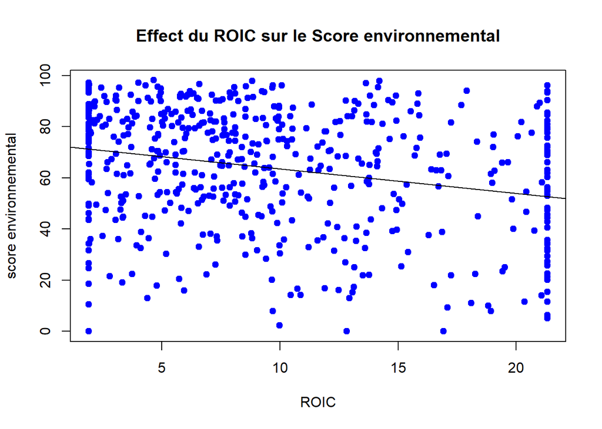

```r
plot(eurostoxx_windsorize$ROIC, eurostoxx_windsorize$`Environment Pillar Score`,
     main = "Effect du ROIC sur le Score environnemental",
     xlab = "ROIC",
     ylab = "score environnemental",
     col = "blue", pch = 19)
abline(lm(eurostoxx_windsorize$`Environment Pillar Score` ~ eurostoxx_windsorize$ROIC))
```

Il semblerait qu’il n’y ait pas de relation entre les membres indépendants et le score environnemental.

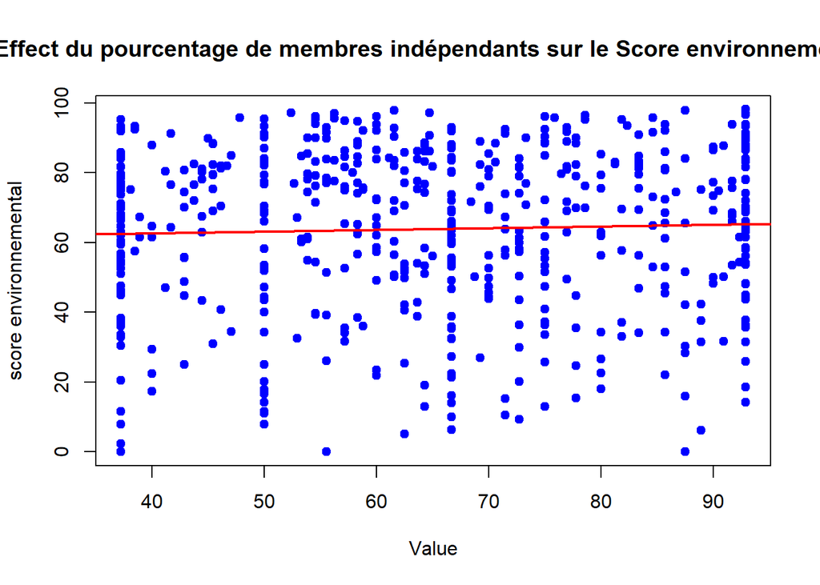

```r
plot(eurostoxx_windsorize$`Value - Board Structure/Independent Board Members`, eurostoxx_windsorize$`Environment Pillar Score`,
     main = "Effect du pourcentage de membres indépendants sur le Score environnemental",
     xlab = "Value",
     ylab = "score environnemental",
     col = "blue", pch = 19)
abline(lm(eurostoxx_windsorize$`Environment Pillar Score` ~ eurostoxx_windsorize$`Value - Board Structure/Independent Board Members`), col = "red", lwd = 2)
```

# PARTIE 4: Modélisation (question 4)

Dans cette partie on va construire notre modèle de régression linéaire pour voir la relation entre nos variables explicatives et la variable du score environnemental et on va tenter d’interpréter les résultats obtenus.

### Construction d’un premier modèle

La première chose qu’on regarde dans le sommaire de notre modèle est la F-Stastistic globale. On voit que notre modèle est globalement significatif avec une valeur P qui est largement inférieure à 5%. Cela signifie qu’au moins une variable dans le modèle explique significativement (est supérieure à 0) la variation du score environnemental.

La deuxième chose qu’on observe est le coefficient de détermination ajusté (Adjusted R squared). Puisque nous sommes en présence d’une régression multiple, on ne se contente pas d’observer le coefficient de détermination (le R squared) puisque celui-ci augmente artificiellement lorsqu’on ajoute des variables dans un modèle, même si elles ne sont pas significatives. On voit donc à travers le coefficient de détermination ajusté que notre modèle explique plus de 37% de la variabilité du score environnemental.

En regardant les coefficients, on voit que le nombre d’employés, le profit opérationnel, les revenus commerciaux nets, le rendement du capital investi, et la non-mise en place d’un comité de soutenabilité CSR contrairement à la mise en place sont significatifs et permettent d’expliquer de façon positive ou négative la variabilité dans le score environnemental.

Les variables comme la capitalisation boursière de l’entreprise et le pourcentage de membre indépendants dans le bureau ne sont pas significatives et donc ne permettent pas d’expliquer la variabilité dans le score environnemental. Les interpréter ne servirait à rien car elles sont jugées comme étant indifférentes de 0.

La variable net sales and revenues représente les revenus commerciaux nets et est aussi fortement significative dans le modèle et aurait un impact positif sur le score environnemental d’une entreprise. Plus les revenus commerciaux nets sont élevés, plus le score environnemental aura tendence également à être plus haut que la moyenne. Ici, quitte à une augmentation d’une unité dans les revenus commerciaux nets d’une entreprise, il y aurait une augmentation de 0.0000002604 unités dans le score environnemental.

La variable ROIC représente le rendement du capital investi. Elle est significative dans notre modèle à hauteur de 5%, mais a un impact négatif sur le score environnemental. Plus le rendement du capital investi augmente, plus le score environnemental aura donc tendance à baisser. Ici, suite à une augmentation d’une unité dans le rendement du capital investi, le score environnemental baisserait de 0.3511 unités.

La variable CSR sustainability committee réprésente la mise en place d’un comité de soutenabilité CSR. Il s’agit d’une variable catégorique et donc R a pris comme catégorie de référence la catégorie ‘Oui’. Le coefficient qui s’affiche ici représente donc la différence de variation dans le score environnemental pour la catégorie ‘Non’ par rapport à la categorie de référence ‘Oui’. Le coefficient est également significatif et donc on observe que lorsqu’une entreprise ne met pas en place un comité de soutenabilité CSR, son score environnemental aura tendence à être plus faible qu’une entreprise qui met en place un comité de soutenabilité CSR. Cette différence est de -19.17, ce qui est énorme étant donné que le score environnemental est un nombre entre 0 et 100. La variable comité de soutenabilité CSR influencerait donc le score environnemental à pratiquement hauteur de 20%. Ceci dit, ce résultat est assez logique puisque la mise en place s’un système CSR au sein des entreprises représente une des premières étapes dans la prise de conscience écologique des entreprises de nos jours.

```r
#On crée notre modèle avec environment pillar score comme variable endogène et le reste comme variables exogènes

predictors <- eurostoxx_windsorize[, -ncol(eurostoxx_windsorize)]
model1 <- lm(`Environment Pillar Score`~ ., data=predictors) #A modifier pour enlever la dernière colonne
#commande pour avoir le sommaire du modèle
print(summary(model1))
```

```
##
## Call:
## lm(formula = `Environment Pillar Score` ~ ., data = predictors)
##
## Residuals:
##     Min      1Q  Median      3Q     Max
## -62.424 -12.105   0.983  12.809  40.230
##
## Coefficients:
##                                                       Estimate Std. Error
## (Intercept)                                          5.601e+01  4.523e+00
## `COUNTRY OF DOMICIL`Bulgarie                         8.034e+00  5.301e+00
## `COUNTRY OF DOMICIL`Bermudes                        -1.988e+01  1.885e+01
## `COUNTRY OF DOMICIL`Danemark                        -1.068e+01  4.937e+00
## `COUNTRY OF DOMICIL`Espagne                          1.345e+01  4.694e+00
## `COUNTRY OF DOMICIL`Finlande                         1.001e+01  5.315e+00
## `COUNTRY OF DOMICIL`France                           8.743e+00  3.385e+00
## `COUNTRY OF DOMICIL`Irlande                         -9.550e+00  6.095e+00
## `COUNTRY OF DOMICIL`Italie                           2.681e+00  4.313e+00
## `COUNTRY OF DOMICIL`Luxembourg                      -4.234e+00  7.493e+00
## `COUNTRY OF DOMICIL`Malte                           -2.853e+01  1.879e+01
## `COUNTRY OF DOMICIL`Pays-Bas                         1.403e+00  4.315e+00
## `COUNTRY OF DOMICIL`Norvège                         -9.092e+00  5.890e+00
## `COUNTRY OF DOMICIL`Autriche                         1.036e+00  7.488e+00
## `COUNTRY OF DOMICIL`Portugal                         1.599e+01  1.101e+01
## `COUNTRY OF DOMICIL`Suède                           -8.296e+00  4.073e+00
## `COUNTRY OF DOMICIL`Suisse                           2.361e-01  3.504e+00
## `COUNTRY OF DOMICIL`Royaume-Uni                     -1.749e+00  2.919e+00
## `COUNTRY OF DOMICIL`Îles Féroé                      -9.192e+00  1.877e+01
## `COUNTRY OF DOMICIL`Île de Man                      -1.357e+01  1.874e+01
## `COUNTRY OF DOMICIL`Pologne                         -1.120e+01  7.562e+00
## EMPLOYEES                                            6.950e-05  3.418e-05
## `OPERATING PROFIT MARGIN`                            1.813e-01  8.867e-02
## `NET SALES OR REVENUES`                              2.604e-07  6.785e-08
## `Market Cap`                                         6.141e-11  4.661e-11
## ROIC                                                -3.511e-01  1.454e-01
## `CSR Sustainability Committee`Non                   -1.917e+01  2.239e+00
## `Value - Board Structure/Independent Board Members`  5.655e-02  5.048e-02
##                                                     t value Pr(>|t|)
## (Intercept)                                          12.382  < 2e-16 ***
```

[output cut: 18 more lines]

```
## `COUNTRY OF DOMICIL`Île de Man                       -0.724 0.469167
## `COUNTRY OF DOMICIL`Pologne                          -1.481 0.139248
## EMPLOYEES                                             2.033 0.042510 *
## `OPERATING PROFIT MARGIN`                             2.044 0.041424 *
## `NET SALES OR REVENUES`                               3.838 0.000139 ***
## `Market Cap`                                          1.318 0.188217
## ROIC                                                 -2.415 0.016062 *
## `CSR Sustainability Committee`Non                    -8.562  < 2e-16 ***
## `Value - Board Structure/Independent Board Members`   1.120 0.263111
## ---
## Signif. codes:  0 '***' 0.001 '**' 0.01 '*' 0.05 '.' 0.1 ' ' 1
##
## Residual standard error: 18.53 on 526 degrees of freedom
## Multiple R-squared:  0.406,  Adjusted R-squared:  0.3755
## F-statistic: 13.31 on 27 and 526 DF,  p-value: < 2.2e-16
```

On crée un deuxième modèle où on ne garde que les variables explicatives. On voit que notre modèle est globalement significatif, mais cependant le coefficient de détermination ajusté est plus faible sur ce dexième modèle que sur le premier. Le premier modèle semble donc être plus judicieux et on gardera les interprétations qu’on a effectué sur le premier modèle.

```r
model2 <- lm(`Environment Pillar Score`~ `COUNTRY OF DOMICIL` + EMPLOYEES  + `OPERATING PROFIT MARGIN`+ `NET SALES OR REVENUES`+ ROIC + `CSR Sustainability Committee`, data=new_eurostoxx)
print(summary(model2))
```

```
##
## Call:
## lm(formula = `Environment Pillar Score` ~ `COUNTRY OF DOMICIL` +
##     EMPLOYEES + `OPERATING PROFIT MARGIN` + `NET SALES OR REVENUES` +
##     ROIC + `CSR Sustainability Committee`, data = new_eurostoxx)
##
## Residuals:
##    Min     1Q Median     3Q    Max
## -62.15 -12.27   1.20  14.23  47.20
##
## Coefficients:
##                                     Estimate Std. Error t value Pr(>|t|)
## (Intercept)                        6.485e+01  2.632e+00  24.641  < 2e-16 ***
## `COUNTRY OF DOMICIL`Bulgarie       8.605e+00  5.501e+00   1.564 0.118352
## `COUNTRY OF DOMICIL`Bermudes      -2.248e+01  1.961e+01  -1.146 0.252292
## `COUNTRY OF DOMICIL`Danemark      -8.495e+00  4.774e+00  -1.779 0.075737 .
## `COUNTRY OF DOMICIL`Espagne        1.589e+01  4.800e+00   3.310 0.000995 ***
## `COUNTRY OF DOMICIL`Finlande       8.725e+00  5.441e+00   1.604 0.109417
## `COUNTRY OF DOMICIL`France         1.045e+01  3.389e+00   3.084 0.002153 **
## `COUNTRY OF DOMICIL`Irlande       -1.103e+01  6.348e+00  -1.738 0.082799 .
## `COUNTRY OF DOMICIL`Italie         2.821e+00  4.483e+00   0.629 0.529464
## `COUNTRY OF DOMICIL`Luxembourg    -3.213e+00  7.780e+00  -0.413 0.679780
## `COUNTRY OF DOMICIL`Malte         -3.284e+01  1.951e+01  -1.683 0.092877 .
## `COUNTRY OF DOMICIL`Pays-Bas       2.508e+00  4.418e+00   0.568 0.570525
## `COUNTRY OF DOMICIL`Norvège       -5.910e+00  5.657e+00  -1.045 0.296611
## `COUNTRY OF DOMICIL`Autriche       2.713e+00  7.728e+00   0.351 0.725703
## `COUNTRY OF DOMICIL`Portugal       1.445e+01  1.143e+01   1.264 0.206794
## `COUNTRY OF DOMICIL`Suède         -3.811e+00  3.751e+00  -1.016 0.310081
## `COUNTRY OF DOMICIL`Suisse         1.192e-01  3.636e+00   0.033 0.973848
## `COUNTRY OF DOMICIL`Royaume-Uni   -2.159e+00  3.022e+00  -0.714 0.475390
## `COUNTRY OF DOMICIL`Îles Féroé    -7.906e+00  1.951e+01  -0.405 0.685470
## `COUNTRY OF DOMICIL`Île de Man    -1.596e+01  1.951e+01  -0.818 0.413471
## `COUNTRY OF DOMICIL`Pologne       -8.363e+00  7.844e+00  -1.066 0.286826
## EMPLOYEES                          2.146e-05  1.299e-05   1.652 0.099082 .
## `OPERATING PROFIT MARGIN`         -2.756e-02  1.590e-02  -1.733 0.083710 .
## `NET SALES OR REVENUES`            1.024e-07  2.058e-08   4.974 8.88e-07 ***
## ROIC                              -4.198e-02  4.089e-02  -1.027 0.305049
## `CSR Sustainability Committee`Non -2.130e+01  2.313e+00  -9.208  < 2e-16 ***
## ---
## Signif. codes:  0 '***' 0.001 '**' 0.01 '*' 0.05 '.' 0.1 ' ' 1
##
## Residual standard error: 19.34 on 528 degrees of freedom
## Multiple R-squared:  0.3504, Adjusted R-squared:  0.3196
## F-statistic: 11.39 on 25 and 528 DF,  p-value: < 2.2e-16
```

Une autre mesure qui permet de comparer les modèles entre eux c’est celle de l’AIC (Akaike Information Criterion). On calcule donc l’AIC des deux modèles qu’on a construit pour pouvoir les comparer entre eux. En règle général on choisit le modèle avec le AIC le moins élevé, et dans notre cas c’est encore le 1er modèle qui semble être plus approprié pour expliquer la variable du score environnemental.

```r
aic_value1 <- AIC(model1)
aic_value2 <- AIC(model2)

aic_value1
```

```
## [1] 4835.932
```

```r
aic_value2
```

```
## [1] 4881.472
```

## Régression avec la variable FI

Maintenant, on inclut la variable Fi qui représente la variabilité financière sur le long terme et on essaye de voir l’impact de cette variable sur le score environnemental. En incluant la variabilité financière sur le long terme, on constate qu’elle est significative au niveau de 1% dans l’explication sur score environnemental et semble suggérer que le score environnemental d’une entreprise varierait dans le même sens que la variabilité financière sur le long terme. Cela pourrait potentiellement s’expliquer par le fait qu’une forte variabilité financière peut pousser une entreprise à adopter des pratiques durables pour se stabiliser, améliorer son image et répondre aux attentes sociales et réglementaires.

```r
model3 <- lm(`Environment Pillar Score`~ ., data=eurostoxx_windsorize)
#commande pour avoir le sommaire du modèle
print(summary(model3))
```

```
##
## Call:
## lm(formula = `Environment Pillar Score` ~ ., data = eurostoxx_windsorize)
##
## Residuals:
##     Min      1Q  Median      3Q     Max
## -63.536 -12.078   0.559  12.511  42.631
##
## Coefficients:
##                                                       Estimate Std. Error
## (Intercept)                                          5.597e+01  4.498e+00
## `COUNTRY OF DOMICIL`Bulgarie                         6.266e+00  5.314e+00
## `COUNTRY OF DOMICIL`Bermudes                        -2.431e+01  1.882e+01
## `COUNTRY OF DOMICIL`Danemark                        -9.879e+00  4.918e+00
## `COUNTRY OF DOMICIL`Espagne                          1.142e+01  4.732e+00
## `COUNTRY OF DOMICIL`Finlande                         9.011e+00  5.300e+00
## `COUNTRY OF DOMICIL`France                           7.873e+00  3.382e+00
## `COUNTRY OF DOMICIL`Irlande                         -1.001e+01  6.063e+00
## `COUNTRY OF DOMICIL`Italie                           1.949e+00  4.298e+00
## `COUNTRY OF DOMICIL`Luxembourg                      -5.312e+00  7.463e+00
## `COUNTRY OF DOMICIL`Malte                           -2.932e+01  1.869e+01
## `COUNTRY OF DOMICIL`Pays-Bas                         5.691e-01  4.302e+00
## `COUNTRY OF DOMICIL`Norvège                         -8.465e+00  5.862e+00
## `COUNTRY OF DOMICIL`Autriche                         1.727e+00  7.451e+00
## `COUNTRY OF DOMICIL`Portugal                         1.290e+01  1.101e+01
## `COUNTRY OF DOMICIL`Suède                           -6.851e+00  4.088e+00
## `COUNTRY OF DOMICIL`Suisse                          -4.870e-01  3.495e+00
## `COUNTRY OF DOMICIL`Royaume-Uni                     -2.686e+00  2.924e+00
## `COUNTRY OF DOMICIL`Îles Féroé                      -1.022e+01  1.866e+01
## `COUNTRY OF DOMICIL`Île de Man                      -1.173e+01  1.865e+01
## `COUNTRY OF DOMICIL`Pologne                         -9.874e+00  7.537e+00
## EMPLOYEES                                            7.851e-05  3.416e-05
## `OPERATING PROFIT MARGIN`                            1.780e-01  8.819e-02
## `NET SALES OR REVENUES`                              2.483e-07  6.763e-08
## `Market Cap`                                         3.869e-11  4.715e-11
## ROIC                                                -2.807e-01  1.470e-01
## `CSR Sustainability Committee`Non                   -1.872e+01  2.234e+00
## `Value - Board Structure/Independent Board Members`  6.171e-02  5.024e-02
## Fi                                                   1.743e+00  6.631e-01
##                                                     t value Pr(>|t|)
```

[output cut: 20 more lines]

```
## `COUNTRY OF DOMICIL`Pologne                          -1.310 0.190734
## EMPLOYEES                                             2.298 0.021937 *
## `OPERATING PROFIT MARGIN`                             2.018 0.044078 *
## `NET SALES OR REVENUES`                               3.672 0.000266 ***
## `Market Cap`                                          0.821 0.412266
## ROIC                                                 -1.909 0.056831 .
## `CSR Sustainability Committee`Non                    -8.379 4.92e-16 ***
## `Value - Board Structure/Independent Board Members`   1.228 0.219881
## Fi                                                    2.628 0.008845 **
## ---
## Signif. codes:  0 '***' 0.001 '**' 0.01 '*' 0.05 '.' 0.1 ' ' 1
##
## Residual standard error: 18.42 on 525 degrees of freedom
## Multiple R-squared:  0.4137, Adjusted R-squared:  0.3824
## F-statistic: 13.23 on 28 and 525 DF,  p-value: < 2.2e-16
```

# Conclusion

ans le travail que nous avons présenté on a tenté de répondre aux questions posées tout en allant plus loin dans notre analyse pour saisir l’effet des variables économiques, commerciales, financières, et de gouvernance sur notre variable environnemental.

Nous avons tout d’abord bien expliqué le choix de la variable environemental score par rapport à celle de carbon intensity pour effectuer notre analyse. Il s’est avéré que la variable carbon intensity était manquante dans notre jeu de données et qu’il n’était donc pas possible d’obtenir des informations sur les émissions de carbone des entreprises.

Par la suite, nous avons bien pris soin de nettoyer notre jeu de données en accomplissant les modifications suivantes:

- Ne conserver que les colonnes dont on a besoin pour l’analyse et les renommer
- Faire en sorte que R reconnaisse les valeurs manquantes (NA)
- Faire en sorte en R différencie entre les variables numériques et catégoriques
- Analyser et traiter les valeurs manquantes en les supprimant ou en les remplaçant par la médiane
- Analyser et traiter les valeurs aberrantes par méthode de windsorisation

On a utilisé la représentation graphique et les statistiques descriptives pour analyser, reconnaître et traiter les problèmes qui pouvaient exister sur notre jeu de données.

Puis on a également utilisé la représentation graphique et les statistiques pour analyser les relations entre nos variables avant de passer à la modélisation.

Une fois nos données prêtes, et après avoir réalisé une analyse de données, nous avons pu modéliser nos données à travers une régression linéaire qui nous a permis de bien saisir la relation entre notre variable endogène (score environnemental) et nos variables exogènes. On a pu voir que le modèle construit était stastiquement significatif et que nos variables ont pu expliquer plus de 34% de la variation dans le score environnemental.

Comme tout travail statistique qui est limité par un temps, on doit toujours faire des choix. Tout au long de ce projet, nous avons tenté d’effectuer les choix qui semblaient être les plus raisonnables, mais bien évidemment d’autres choix auraient pût être fait et auraient peut-être conclus à un modèle qui explique une plus grande partie de la variation de notre variable d’intérêt. Dans le futur, on peut ajouter d’autres variables, traiter les valeurs manquantes ou aberrantes de façon différente. D’autres analyses suite à la régression peuvent également être faites pour détecter si il y a des problèmes de multiculinarité, de hétéroscédasticité ou d’endogeneité dans le modèle. D’autres modèles de régression comme les GLM peuvent également être mis en place et comparer avec le modèle que nous avons construit dans cette analyse.